# STA302 Group Project Final Markdown File

Callum Lang, Khilna Poojari, San Singh, and Pavritha Venkitaraman

This Markdown file demonstrates the process used to clean and subset the data, produce a summary table of the variables in the model, fit the model, and conduct the residual analysis for checking the model’s assumptions for the proposal and final parts of the project.

# Project Proposal

## Data Cleaning and Subsetting

The `tidyverse`, `readxl`, and `flextable` libraries are loaded to read the car insurance data and store it as a data frame object.

```r
library(tidyverse)
library(readxl)
library(flextable)
cid <- read.csv("car_insurance_claim.csv")
```

We begin by converting the columns expressing dollar amounts in character type to numeric.

```r
cid$INCOME <- as.numeric(gsub("[//$,]", "", cid$INCOME))
cid$BLUEBOOK <- as.numeric(gsub("[//$,]", "", cid$BLUEBOOK))
cid$CLM_AMT <- as.numeric(gsub("[//$,]", "", cid$CLM_AMT))
```

We then create a new data frame object with the predictor and response variables relevant to our model, starting with the response (claim_amount), followed by the numerical and then categorical predictors.

```r
cidf <- data.frame(claim_amount = cid$CLM_AMT, age = cid$AGE, income = cid$INCOME,
                   car_age = cid$CAR_AGE, bluebook = cid$BLUEBOOK,
                   mvr_points = cid$MVR_PTS, car_type = cid$CAR_TYPE)
```

```r
cidf <- na.omit(cidf)
cidf <- cidf[cidf$car_age >= 0, ]
cidf <- cidf[cidf$claim_amount != 0, ]
cidf$car_type <- as.factor(gsub("z_", "", cidf$car_type))
```

Finally, the cleaned data is exported to a csv file called `car_insurance_claim_cleaned.csv`.

```r
write.csv(cidf, "car_insurance_claim_cleaned.csv", row.names = FALSE)
```

## Summary Table for the Variables in the Model

We construct a table by creating a data frame object which provides the description, type, mean, median, minimum, maximum, standard deviation, and a brief written description of the distribution of each variable used in the model.

In order to create a written description of the distribution of each variable in the model, we create a histogram for each variable and then visually examine.

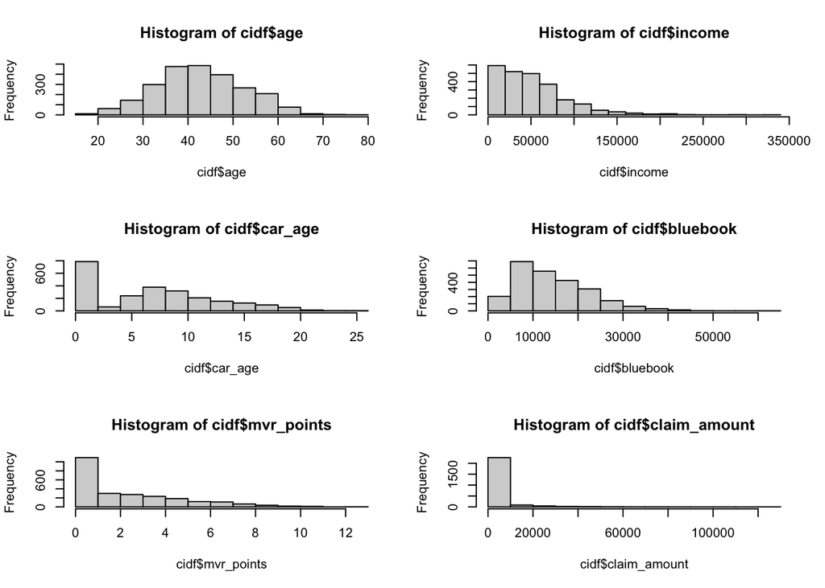

```r
par(mfrow = c(3,2))
hist(cidf$age)
hist(cidf$income)
hist(cidf$car_age)
hist(cidf$bluebook)
hist(cidf$mvr_points)
hist(cidf$claim_amount)
```

```r
# construct a data frame object to hold the table's contents
summary_table <- data.frame(
  Variable = c("age", "income", "car_age", "bluebook", "mvr_points", "car_type",
               "claim_amount"),
  Description = c("Age of the driver in years.",
                  "Annual income of the driver in dollars.",
                  "Age of the car since produced in years.",
                  "Estimated value of the vehicle in dollars.",
                  "Motor Vehicle Record Points.", "Type of vehicle.",
                  "Amount paid out for the insurance claim."),
  Type = c("Numerical Predictor", "Numerical Predictor", "Numerical Predictor",
           "Numerical Predictor", "Numerical Predictor",
           "Categorical Predictor", "Numerical Response"),
  Mean = c(round(mean(cidf$age), digits = 4),
           round(mean(cidf$income), digits = 4),
           round(mean(cidf$car_age), digits = 4),
           round(mean(cidf$bluebook), digits = 4),
           round(mean(cidf$mvr_points), digits = 4),
           "N/A", round(mean(cidf$claim_amount), digits = 4)),
  Median = c(median(cidf$age), median(cidf$income), median(cidf$car_age),
             median(cidf$bluebook), median(cidf$mvr_points),
             "N/A", median(cidf$claim_amount)),
  Min = c(min(cidf$age), min(cidf$income), min(cidf$car_age),
              min(cidf$bluebook), min(cidf$mvr_points), "N/A",
              min(cidf$claim_amount)),
  Max = c(max(cidf$age), max(cidf$income), max(cidf$car_age),
              max(cidf$bluebook), max(cidf$mvr_points), "N/A",
              max(cidf$claim_amount)),
  Std_Dev = c(round(sd(cidf$age), digits = 4),
                         round(sd(cidf$income), digits = 4),
                         round(sd(cidf$car_age), digits = 4),
                         round(sd(cidf$bluebook), digits = 4),
                         round(sd(cidf$mvr_points), digits = 4), "N/A",
                         round(sd(cidf$claim_amount), digits = 4)),
  Distribution = c("Fairly normal, no skews or outliers.", "Heavily right-skewed
                   with outliers around $300,000.", "Histogram is right-skewed,
                   with a high number of observations in the 0-2.5 year bin,
                   followed by a low number of observations in the 2.5-5 year
                   bin.", "Heavily right-skewed.", "Heavily right-skewed with
                   roughly half the observations in the 0-1 bin.", "Summary of
                   counts: Minivan: 411, Panel Truck: 205, Pickup: 499,
                   Sports Car: 355, SUV: 749, Van: 220", "Very right-skewed,
                   with the majority of observations lying in the
                   $0 - $10,000 bin and outliers at $123,247, $107,586,
                   $85,524, and $78,874."))
```

The data frame object is then converted into a flextable object so that the width, font style, font size, font bolding, padding, and alignment can be adjusted to make the table more readable.

```r
# convert data frame object into a flextable object
ft <- flextable(summary_table)

#adjust appearance of flextable object
ft <- set_table_properties(ft, layout = "autofit", width = 1)
ft <- font(ft, fontname = "Arial", part = "all")
ft <- fontsize(ft, size = 9, part = "all")
ft <- bold(ft, part = "header")
ft <- padding(ft, padding = 2, part = "all")
ft <- align(ft, align = "left", part = "all")
```

These adjustments result in the final output:

| Variable | Description | Type | Mean | Median | Min | Max | Std_Dev | Distribution |
| --- | --- | --- | --- | --- | --- | --- | --- | --- |
| age | Age of the driver in years. | Numerical Predictor | 43.2744 | 43 | 16 | 76 | 9.6658 | Fairly normal, no skews or outliers. |
| income | Annual income of the driver in dollars. | Numerical Predictor | 50432.4397 | 43567 | 0 | 320127 | 42292.3492 | Heavily right-skewed with outliers around $300,000. |
| car_age | Age of the car since produced in years. | Numerical Predictor | 7.2691 | 7 | 0 | 25 | 5.5136 | Histogram is right-skewed, with a high number of observations in the 0-2.5 year bin, followed by a low number of observations in the 2.5-5 year bin. |
| bluebook | Estimated value of the vehicle in dollars. | Numerical Predictor | 14272.2395 | 12630 | 1500 | 62240 | 8264.6403 | Heavily right-skewed. |
| mvr_points | Motor Vehicle Record Points. | Numerical Predictor | 2.5398 | 2 | 0 | 13 | 2.5933 | Heavily right-skewed with roughly half the observations in the 0-1 bin. |
| car_type | Type of vehicle. | Categorical Predictor | N/A | N/A | N/A | N/A | N/A | Summary of counts: Minivan: 411, Panel Truck: 205, Pickup: 499, Sports Car: 355, SUV: 749, Van: 220 |
| claim_amount | Amount paid out for the insurance claim. | Numerical Response | 5687.4774 | 4147.5 | 30 | 123247 | 7852.6955 | Very right-skewed, with the majority of observations lying in the $0 - $10,000 bin and outliers at $123,247, $107,586, $85,524, and $78,874. |

We then fit a linear model with these variables.

## Model Fitting and Checking of Assumptions

We first construct a linear model from the cleaned data by relating our response (claim_amount) to our predictors (age, income, car_age, bluebook, mvr_points, and car_type) with the lm function. We then examine the model’s Residual vs Fitted plot and Q-Q plot.

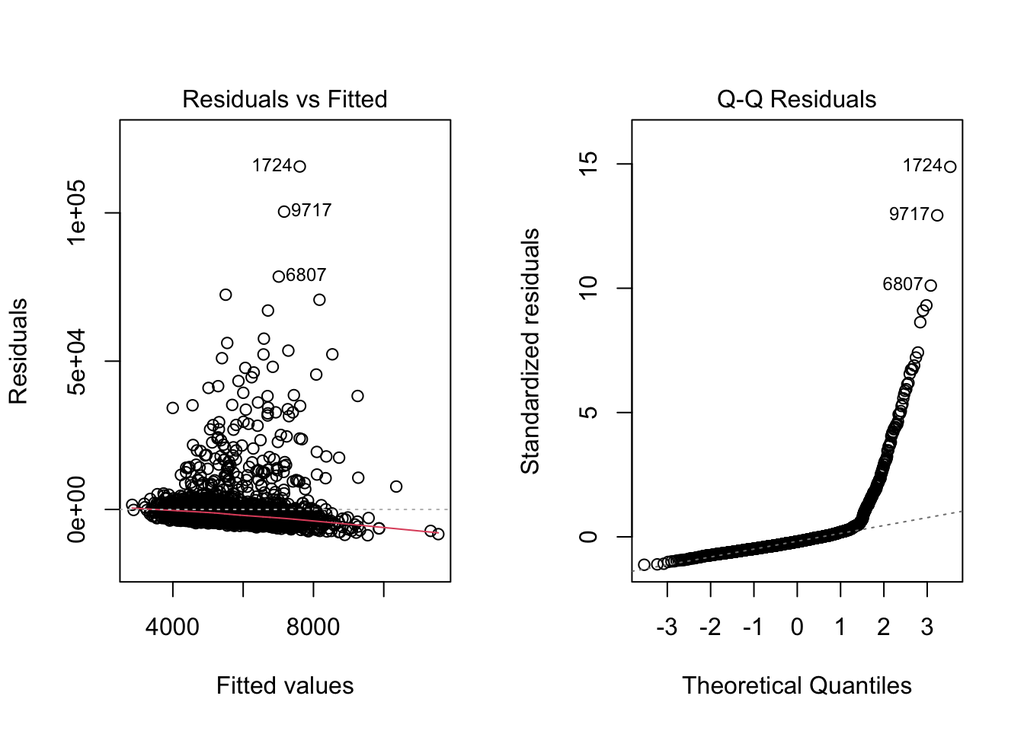

```r
# construct linear model
linear_model <- lm(claim_amount ~ age + income + car_age + bluebook +
                     mvr_points + car_type, data = cidf)
# create the residuals vs fitted values plot and Q-Q plot side-by-side
par(mfrow = c(1,2))
plot(linear_model, which = 1)
plot(linear_model, which = 2)
```

The model does not yield satisfactory results because it violates the linearity assumption and constant variance assumption, which is observed by the residual vs fitted plot having a non-constant vertical spread and a mean that decreases as fitted values increase. Additionally, the normality of errors assumption is violated since the standardized residuals of the model significantly deviate from the larger theoretical quantiles.

In search of better results, we attempt a log transformation on the response variable, again using the lm function, and then perform the same plots as before to compare results.

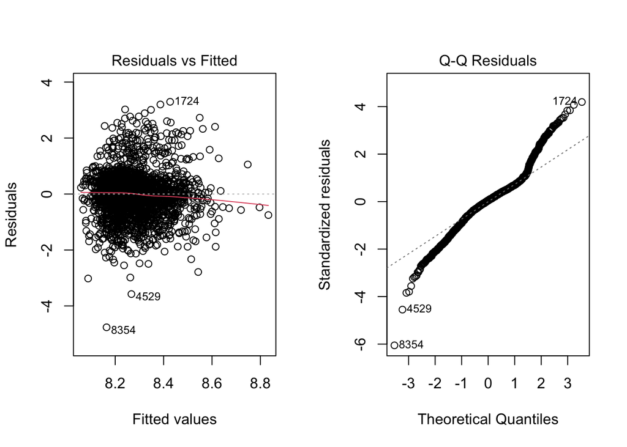

```r
# construct linear model with log response variable
log_linear_model <- lm(log(claim_amount) ~  age + income + car_age + bluebook +
                        mvr_points + car_type, data = cidf)
# create the residuals vs fitted values plot and Q-Q plot side-by-side
par(mfrow = c(1,2))
plot(log_linear_model, which = 1)
plot(log_linear_model, which = 2)
```

The log transformation shows improvements over the original linear model. The residuals vs fitted plot is closer to a null plot and has a less negative mean for larger fitted values, while the Q-Q plot has standardized residuals that are overall closer to their corresponding theoretical quantile. However, still none of these characteristics of the plots are well-behaved enough for any of our model’s assumptions to hold.

# Final Project

## Data Cleaning and Subsetting

```r
library(tidyverse)
library(readxl)
library(knitr)
library(kableExtra)
library(car)
cid <- read.csv("car_insurance_claim.csv")
```

We begin by converting all the columns in the data set expressing dollar amounts in character type to numeric.

```r
cid$INCOME <- as.numeric(gsub("[//$,]", "", cid$INCOME))
cid$BLUEBOOK <- as.numeric(gsub("[//$,]", "", cid$BLUEBOOK))
cid$CLM_AMT <- as.numeric(gsub("[//$,]", "", cid$CLM_AMT))
cid$HOME_VAL <- as.numeric(gsub("[//$,]", "", cid$HOME_VAL))
cid$OLDCLAIM <- as.numeric(gsub("[//$,]", "", cid$OLDCLAIM))
```

We then create a new, bigger data frame object than the one used in the project proposal that contains all the predictors and our response variable `claim_amount`, except for `ID` because no statistical information can be derived from it, and `BIRTHDAY`, because we already have age as a predictor. The data frame begins with the response in the first column, followed by all the predictors ordered as they appear in the original `.csv` file.

```r
cidf_big <- data.frame(claim_amount = cid$CLM_AMT, age = cid$AGE,
                       kids_driven = cid$KIDSDRIV,homekids = cid$HOMEKIDS,
                       years_on_job = cid$YOJ, income = cid$INCOME,
                       parent = cid$PARENT1, home_value = cid$HOME_VAL,
                       marriage_status = cid$MSTATUS, gender = cid$GENDER,
                       education = cid$EDUCATION, occupation = cid$OCCUPATION,
                       travel_time = cid$TRAVTIME, car_use = cid$CAR_USE,
                       bluebook = cid$BLUEBOOK, total_insurable_value = cid$TIF,
                       car_type = cid$CAR_TYPE, red_car = cid$RED_CAR,
                       old_claim = cid$OLDCLAIM, claim_frequency = cid$CLM_FREQ,
                       revoked = cid$REVOKED, mvr_points = cid$MVR_PTS,
                       car_age = cid$CAR_AGE, claim_flag = cid$CLAIM_FLAG,
                       urbanicity = cid$URBANICITY)
```

Additionally, many levels of some categorical variables contained “z_” prefixes, which were removed for improved readability.

```r
cidf_big <- na.omit(cidf_big)
cidf_big <- cidf_big[cidf_big$car_age >= 0, ]
cidf_big <- cidf_big[cidf_big$claim_amount != 0, ]

# remove "z_" prefixes from various categories for improved readability
cidf_big$marriage_status <- as.factor(gsub("z_", "", cidf_big$marriage_status))
cidf_big$education <- as.factor(gsub("z_", "", cidf_big$education))
cidf_big$occupation <- as.factor(gsub("z_", "", cidf_big$occupation))
cidf_big$car_type <- as.factor(gsub("z_", "", cidf_big$car_type))
cidf_big$parent <- as.factor(gsub("z_", "", cidf_big$parent))
cidf_big$car_use <- as.factor(gsub("z_", "", cidf_big$car_use))
cidf_big$urbanicity <- as.factor(gsub("z_", "", cidf_big$urbanicity))
cidf_big$gender <- as.factor(gsub("z_", "", cidf_big$gender))
```

Finally, the cleaned data is exported to a `.csv` file called `car_insurance_claim_cleaned_v2.csv`.

```r
write.csv(cidf_big, "car_insurance_claim_cleaned_v2.csv", row.names = FALSE)
```

## Model Selection Process

### Transformation Selection

Prior to revising the initial model further, we fit the initial model to the new, revised data set so we can make more direct comparisons between the initial model and any other transformed models on the new data set.

```r
log_linear_model_new <- lm(log(claim_amount) ~ age + income + car_age +
                             bluebook + mvr_points + car_type, data = cidf_big)
```

In search of a more satisfactory transformation, we attempt a 10th root transformation on the response instead of a log transformation.

```r
log_lm_10root <-lm(I(claim_amount^0.1) ~ age + income + car_age + bluebook + mvr_points +
           car_type, data = cidf_big)
```

We then plot these two models to compare results.

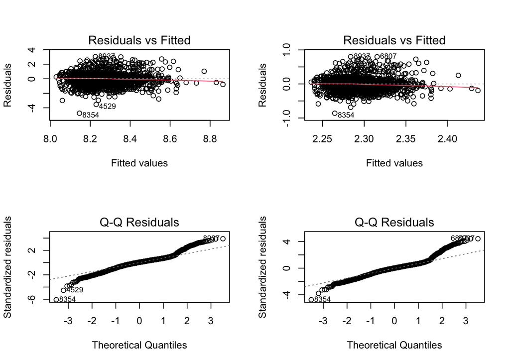

```r
par(mfrow = c(2, 2))
# first row: residuals vs. fitted plots
plot(log_linear_model_new, which = 1)
plot(log_lm_10root, which = 1)
# second row: Q-Q plots
plot(log_linear_model_new, which = 2)
plot(log_lm_10root, which = 2)
```

We then compare their `summary()` calls, alongside their `AIC` and `BIC` scores

```r
summary(log_linear_model_new)
```

```
##
## Call:
## lm(formula = log(claim_amount) ~ age + income + car_age + bluebook +
##     mvr_points + car_type, data = cidf_big)
##
## Residuals:
##     Min      1Q  Median      3Q     Max
## -4.7449 -0.3858  0.0421  0.3877  3.0375
##
## Coefficients:
##                       Estimate Std. Error t value Pr(>|t|)
## (Intercept)          8.068e+00  8.968e-02  89.967  < 2e-16 ***
## age                 -7.671e-04  1.775e-03  -0.432   0.6656
## income               1.960e-07  4.836e-07   0.405   0.6852
## car_age             -2.473e-03  3.398e-03  -0.728   0.4668
## bluebook             1.115e-05  2.714e-06   4.109 4.13e-05 ***
## mvr_points           1.221e-02  6.479e-03   1.884   0.0597 .
## car_typePanel Truck  1.012e-01  8.074e-02   1.254   0.2100
## car_typePickup       3.360e-02  5.566e-02   0.604   0.5461
## car_typeSports Car   3.302e-02  6.017e-02   0.549   0.5833
## car_typeSUV          9.696e-02  5.132e-02   1.889   0.0590 .
## car_typeVan          4.200e-02  7.155e-02   0.587   0.5573
## ---
## Signif. codes:  0 '***' 0.001 '**' 0.01 '*' 0.05 '.' 0.1 ' ' 1
##
## Residual standard error: 0.7826 on 2177 degrees of freedom
## Multiple R-squared:  0.01885,    Adjusted R-squared:  0.01435
## F-statistic: 4.183 on 10 and 2177 DF,  p-value: 9.168e-06
```

```r
summary(log_lm_10root)
```

```
##
## Call:
## lm(formula = I(claim_amount^0.1) ~ age + income + car_age + bluebook +
##     mvr_points + car_type, data = cidf_big)
##
## Residuals:
##      Min       1Q   Median       3Q      Max
## -0.85963 -0.09436  0.00273  0.08355  0.80055
##
## Coefficients:
##                       Estimate Std. Error t value Pr(>|t|)
## (Intercept)          2.246e+00  2.076e-02 108.176  < 2e-16 ***
## age                 -1.734e-04  4.109e-04  -0.422   0.6731
## income               5.235e-08  1.120e-07   0.468   0.6402
## car_age             -7.148e-04  7.867e-04  -0.909   0.3636
## bluebook             2.687e-06  6.284e-07   4.276 1.98e-05 ***
## mvr_points           2.733e-03  1.500e-03   1.822   0.0686 .
## car_typePanel Truck  2.282e-02  1.869e-02   1.221   0.2223
## car_typePickup       8.142e-03  1.289e-02   0.632   0.5276
## car_typeSports Car   7.971e-03  1.393e-02   0.572   0.5673
## car_typeSUV          2.226e-02  1.188e-02   1.874   0.0611 .
## car_typeVan          9.131e-03  1.657e-02   0.551   0.5816
## ---
## Signif. codes:  0 '***' 0.001 '**' 0.01 '*' 0.05 '.' 0.1 ' ' 1
##
## Residual standard error: 0.1812 on 2177 degrees of freedom
## Multiple R-squared:  0.01976,    Adjusted R-squared:  0.01526
## F-statistic: 4.389 on 10 and 2177 DF,  p-value: 3.988e-06
```

```r
AIC(log_linear_model_new)
```

```
## [1] 5149.736
```

```r
BIC(log_linear_model_new)
```

```
## [1] 5218.025
```

```r
AIC(log_lm_10root)
```

```
## [1] -1252.471
```

```r
BIC(log_lm_10root)
```

```
## [1] -1184.182
```

We find that the 10th root transformation leads to a model with a similar residuals vs. fitted values plot, while improving the left tail of the QQ plot (residuals are less extreme), while the right tail is slightly heavier. Further, the 10th root’s model has a higher adjusted R squared, and vastly lower AIC and BIC scores in comparison to the log model. As a result, we chose to use the 10th root transformation on the response for our revised model.

### Variable Selection

We then reconsidered which variables to use in the revised model. Given the large number of predictors in the data set, we used three automated methods (Backward Elimination, Forward Selection, and Stepwise Regression) with AIC and BIC as the information criterion. We then compared each model’s adjusted R squared, AIC, and BIC scores as criteria, and chose the model that performed best overall.

We begin by building a linear model that uses all the predictors in the data set, `full_linear_model`, to use for backward elimination.

```r
full_linear_model <- lm(I(claim_amount^0.1) ~ age + kids_driven + homekids +
                          years_on_job + income + parent + home_value +
                          marriage_status + gender + education + occupation +
                          travel_time + car_use + bluebook + total_insurable_value +
                          car_type + red_car + old_claim + claim_frequency + revoked +
                          mvr_points + car_age + urbanicity,
                        data = cidf_big)
```

We then use the `step` function to perform backward elimination using AIC and BIC as the information criterion.

```r
# build model with AIC as criteria
aic_back_model <- step(full_linear_model, direction = "backward", k = 2)

summary(aic_back_model)
AIC(aic_back_model)
BIC(aic_back_model)

# build model with BIC as criteria
bic_back_model <- step(full_linear_model, direction = "backward", k = log(nrow(cidf_big)))
```

We then build a null model to use with forward elimination and stepwise regression.

```r
null_model <- lm(I(claim_amount^0.1) ~ 1, data = cidf_big)
```

We then use the `step` function to perform forward selection using AIC and BIC as the information criterion.

```r
# build model with AIC as criteria
aic_for_model <- step(null_model,
                      scope = list(lower = null_model, upper = full_linear_model),
                      direction = "forward", k = 2)

# build model with BIC as criteria
bic_for_model <- step(null_model,
                      scope = list(lower = null_model, upper = full_linear_model),
                      direction = "forward", k = log(nrow(cidf_big)))
```

We then use the `step` function to perform stepwise regression using AIC and BIC as the information criterion.

```r
# build model with AIC as criteria
aic_stepwise_model <- step(null_model,
                           scope = list(lower = null_model, upper = full_linear_model),
                           direction = "both", k = 2)

# build model with BIC as criteria
bic_stepwise_model <- step(null_model,
                           scope = list(lower = null_model, upper = full_linear_model),
                           direction = "both", k = log(nrow(cidf_big)))
```

We then compare the adjusted R squared, AIC, and BIC of these models.

```
##          Model Adjusted_R2       AIC       BIC
## 1 Backward AIC  0.01865155 -1264.002 -1218.476
## 2 Backward BIC  0.01513184 -1261.158 -1244.086
## 3  Forward AIC  0.01808543 -1265.733 -1237.279
## 4  Forward BIC  0.01513184 -1261.158 -1244.086
## 5 Stepwise AIC  0.01808543 -1265.733 -1237.279
## 6 Stepwise BIC  0.01513184 -1261.158 -1244.086
```

It is observed that the forward selection AIC model and the stepwise regression AIC model have the same scores, and the best overall scores. They are in fact the same model, as shown by their summary outputs below. We will refer to this model as the forward AIC model from here onwards.

```r
summary(aic_for_model)
```

```
##
## Call:
## lm(formula = I(claim_amount^0.1) ~ bluebook + marriage_status +
##     mvr_points, data = cidf_big)
##
## Residuals:
##      Min       1Q   Median       3Q      Max
## -0.85353 -0.09441  0.00263  0.08536  0.79679
##
## Coefficients:
##                      Estimate Std. Error t value Pr(>|t|)
## (Intercept)         2.256e+00  9.618e-03 234.513  < 2e-16 ***
## bluebook            2.776e-06  4.675e-07   5.938 3.36e-09 ***
## marriage_statusYes -1.726e-02  7.741e-03  -2.230   0.0259 *
## mvr_points          2.760e-03  1.492e-03   1.850   0.0645 .
## ---
## Signif. codes:  0 '***' 0.001 '**' 0.01 '*' 0.05 '.' 0.1 ' ' 1
##
## Residual standard error: 0.1809 on 2184 degrees of freedom
## Multiple R-squared:  0.01943,    Adjusted R-squared:  0.01809
## F-statistic: 14.43 on 3 and 2184 DF,  p-value: 2.625e-09
```

```r
summary(aic_stepwise_model)
```

```
##
## Call:
## lm(formula = I(claim_amount^0.1) ~ bluebook + marriage_status +
##     mvr_points, data = cidf_big)
##
## Residuals:
##      Min       1Q   Median       3Q      Max
## -0.85353 -0.09441  0.00263  0.08536  0.79679
##
## Coefficients:
##                      Estimate Std. Error t value Pr(>|t|)
## (Intercept)         2.256e+00  9.618e-03 234.513  < 2e-16 ***
## bluebook            2.776e-06  4.675e-07   5.938 3.36e-09 ***
## marriage_statusYes -1.726e-02  7.741e-03  -2.230   0.0259 *
## mvr_points          2.760e-03  1.492e-03   1.850   0.0645 .
## ---
## Signif. codes:  0 '***' 0.001 '**' 0.01 '*' 0.05 '.' 0.1 ' ' 1
##
## Residual standard error: 0.1809 on 2184 degrees of freedom
## Multiple R-squared:  0.01943,    Adjusted R-squared:  0.01809
## F-statistic: 14.43 on 3 and 2184 DF,  p-value: 2.625e-09
```

To check for any missing variables that the forward selection process may have missed, we conduct an ANOVA test between the forward AIC model and the full model.

```r
# ANOVA between revised and og model to show it is better
anova(aic_for_model, full_linear_model)
```

```
## Analysis of Variance Table
##
## Model 1: I(claim_amount^0.1) ~ bluebook + marriage_status + mvr_points
## Model 2: I(claim_amount^0.1) ~ age + kids_driven + homekids + years_on_job +
##     income + parent + home_value + marriage_status + gender +
##     education + occupation + travel_time + car_use + bluebook +
##     total_insurable_value + car_type + red_car + old_claim +
##     claim_frequency + revoked + mvr_points + car_age + urbanicity
##   Res.Df    RSS Df Sum of Sq      F Pr(>F)
## 1   2184 71.508
## 2   2150 70.556 34   0.95187 0.8531   0.71
```

Since the p-value (Pr(>F)) is greater than 0.05, we fail to reject the null, and therefore there is a lack of evidence that all the variables omitted from the forward AIC model collectively explain additional variation in the response beyond the predictors already present.

## Gathering of Statistics and Figures for Analysis

In addition to R squared, AIC and BIC, we gather the Residual Standard Error, adjusted R squared, F-statistic and P-value for the model to present in the report.

```r
stat_table <- data.frame(Statistic = c("Residual Standard Error", "R Squared",
                                       "Adjusted R Squared", "AIC", "BIC",
                                       "F-Statistic", "P-value"),
                         Result = c(summary(aic_for_model)$sigma,
                                    summary(aic_for_model)$r.squared,
                                    summary(aic_for_model)$adj.r.squared,
                                    AIC(aic_for_model), BIC(aic_for_model),
                                        summary(aic_for_model)$fstatistic[1],
                                        with(as.list(summary(aic_for_model)$fstatistic),
                                             pf(value, numdf, dendf, lower.tail = FALSE)))

)
```

```
##                 Statistic        Result
## 1 Residual Standard Error  1.809467e-01
## 2               R Squared  1.943236e-02
## 3      Adjusted R Squared  1.808543e-02
## 4                     AIC -1.265733e+03
## 5                     BIC -1.237279e+03
## 6             F-Statistic  1.442711e+01
## 7                 P-value  2.625232e-09
```

We then check for multicollinearity in the predictors.

```r
vif(aic_for_model)
```

```
##        bluebook marriage_status      mvr_points
##        1.003301        1.000834        1.003344
```

Since the variance inflation factors are very close to 1, we conclude that there is little to no multicollinearity amongst the predictors.

We then create the residuals vs. fitted values and Q-Q plots to determine if the forward AIC model follows the linear model assumptions.

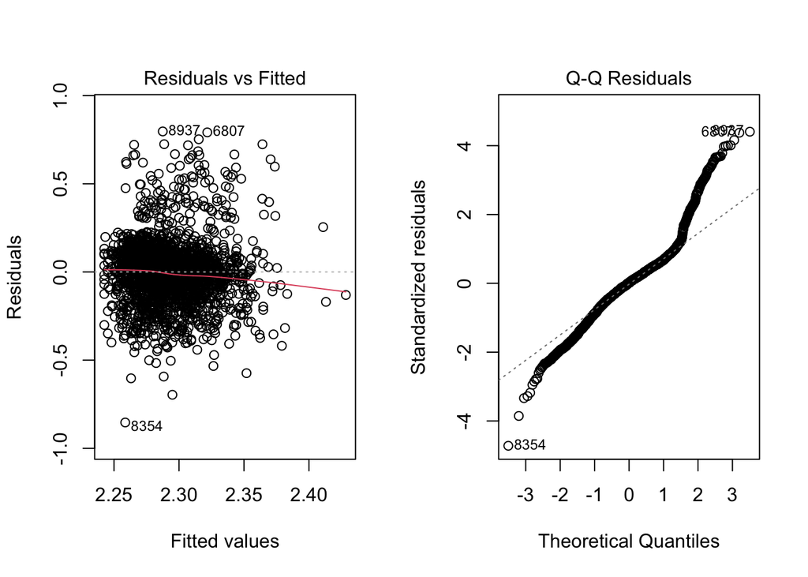

```r
# residuals vs fitted and Q-Q plot
# arrange plots in a 1 x 2 matrix
par(mfrow = c(1, 2))
# Residuals vs Fitted plot
plot(aic_for_model, which = 1)
# QQ plot
plot(aic_for_model, which = 2)
```

In the revised model’s residuals vs fitted values plot, we observe an uneven dispersion of points, a mean that decreases from zero, and the spread of the positive and negative residuals varying differently as fitted values increase. Therefore, we conclude that the linearity and homoskedasticity assumptions are violated. Further, we observe that the Q-Q plot shows a heavy left tail and very heavy right tail in the distribution of the standardized residuals, indicating that the model violates the normality of errors assumption.

We then create a summary of the variables in the model for use in the report. The descriptions of the variable distributions come from the following plots (and table for `marriage_status`, since it is categorical):

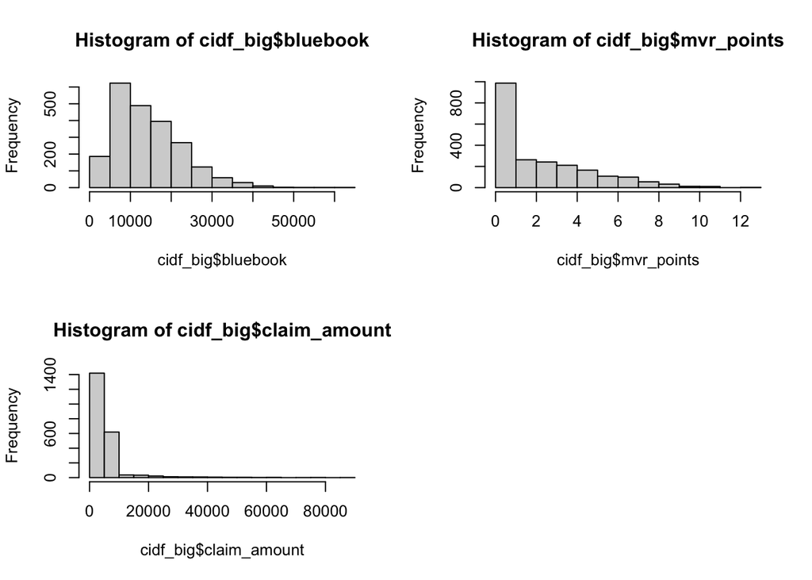

```
##
##   No  Yes
## 1111 1077
```

```r
# Summary of Variables

# Make a flextable with a description Mean, Median, SD, Max/min, and a
# distribution description for each variable in cidf_big.
revised_summary_table <- data.frame(
  Variable = c("bluebook", "mvr_points", "marriage_status",
               "claim_amount"),
  Description = c("Estimated value of the vehicle in dollars.",
                  "Motor Vehicle Record Points.", "Maritial status of the driver.",
                  "Amount paid out for the insurance claim."),
  Type = c("Numerical Predictor", "Numerical Predictor", "Categorical Predictor",
           "Numerical Response"),
  Mean = c(round(mean(cidf_big$bluebook), digits = 4),
           round(mean(cidf_big$mvr_points), digits = 4),
           "N/A", round(mean(cidf_big$claim_amount), digits = 4)),
  Median = c(median(cidf_big$bluebook), median(cidf_big$mvr_points),
             "N/A", median(cidf_big$claim_amount)),
  Min = c(min(cidf_big$bluebook), min(cidf_big$mvr_points), "N/A",
          min(cidf_big$claim_amount)),
  Max = c(max(cidf_big$bluebook), max(cidf_big$mvr_points), "N/A",
          max(cidf_big$claim_amount)),
  Std_Dev = c(round(sd(cidf_big$bluebook), digits = 4),
              round(sd(cidf_big$mvr_points), digits = 4), "N/A",
              round(sd(cidf_big$claim_amount), digits = 4)),
  Distribution = c("Very right-skewed with centre in the $5000 - $10,000 bin.",
                   "Extremely right-skewed with roughly half the observations in
                   the 0-1 bin.", "Category Counts: No: 1111, Yes: 1077",
                   "Very right-skewed, with the majority of observations lying
                   in the $0 - $5,000 bin, with outliers at $85,524, $78,874,
                   and $77,907."))
```

We then format the table to make it more presentable for the final report:

```r
rft <- flextable(revised_summary_table)
rft <- set_table_properties(rft, layout = "autofit", width = 1)
rft <- font(rft, fontname = "Arial", part = "all")
rft <- fontsize(rft, size = 9, part = "all")
rft <- bold(rft, part = "header")
rft <- padding(rft, padding = 2, part = "all")
rft <- align(rft, align = "left", part = "all")
```

| Variable | Description | Type | Mean | Median | Min | Max | Std_Dev | Distribution |
| --- | --- | --- | --- | --- | --- | --- | --- | --- |
| bluebook | Estimated value of the vehicle in dollars. | Numerical Predictor | 14249.3282 | 12615 | 1500 | 62240 | 8290.8074 | Very right-skewed with centre in the $5000 - $10,000 bin. |
| mvr_points | Motor Vehicle Record Points. | Numerical Predictor | 2.5338 | 2 | 0 | 13 | 2.5981 | Extremely right-skewed with roughly half the observations in the 0-1 bin. |
| marriage_status | Maritial status of the driver. | Categorical Predictor | N/A | N/A | N/A | N/A | N/A | Category Counts: No: 1111, Yes: 1077 |
| claim_amount | Amount paid out for the insurance claim. | Numerical Response | 5574.559 | 4133 | 30 | 85524 | 7330.0173 | Very right-skewed, with the majority of observations lying in the $0 - $5,000 bin, with outliers at $85,524, $78,874, and $77,907. |

## Treatment of Leverage points, Influential points, and Outliers

We then search for leverage points, influential points, and outliers in the model. It should be noted that since the data set came with no additional information, we had to use our best judgment when interpreting what each variable measures based on their names. This is also applied to the levels of the categorical variables. Specifically, the `occupation` level which is blank was taken to mean unemployed, and any `income` reported is the income of their most recent job, should it be greater than zero. This decision was made to accommodate for potential misconceptions we may have about what `occupation` and `income` represent as variables.

Beginning with leverage points, we determine the cutoff value for high leverage and count how many observations are high leverage.

```r
# leverage cutoff is > 2(p+1)/n:
leverage_cutoff <- 2 * length(coef(aic_for_model)) / nobs(aic_for_model)

# count how many high leverage points the model has
sum(hatvalues(aic_for_model) > leverage_cutoff)
```

```
## [1] 128
```

We then examine the residuals of the high leverage observations to determine how many of them are bad leverage points, meaning they are high leverage and have a standardized residual greater than 4 in magnitude.

```r
# get indexes of high leverage values in model
high_lev_idx <- which(hatvalues(aic_for_model) > leverage_cutoff)

# find how many high leverage observations have a large standardized residual
sum(abs(rstandard(aic_for_model)[high_lev_idx]) > 4)
```

```
## [1] 1
```

We thus conclude that the model has one bad leverage point. We examine the observation:

```r
# bad leverage point index
bad_lev_pt <- which(abs(rstandard(aic_for_model)[high_lev_idx]) > 4)

# create table
kable(cidf_big[bad_lev_pt, ], format = "html") %>%
  kable_styling(full_width = FALSE) %>%
  column_spec(
    1:ncol(cidf_big[bad_lev_pt, ]),
    extra_css = "min-width: 130px; padding-left: 15px; padding-right: 15px; white-space: nowrap;"
  ) %>%
  scroll_box(width = "100%", height = "140px")
```

|  | claim_amount | age | kids_driven | homekids | years_on_job | income | parent | home_value | marriage_status | gender | education | occupation | travel_time | car_use | bluebook | total_insurable_value | car_type | red_car | old_claim | claim_frequency | revoked | mvr_points | car_age | claim_flag | urbanicity |
| --- | --- | --- | --- | --- | --- | --- | --- | --- | --- | --- | --- | --- | --- | --- | --- | --- | --- | --- | --- | --- | --- | --- | --- | --- | --- |
| 557 | 4313 | 27 | 0 | 3 | 9 | 69794 | Yes | 0 | No | F | Bachelors | Professional | 24 | Private | 14660 | 4 | SUV | no | 2848 | 1 | No | 3 | 6 | 1 | Highly Urban/ Urban |

It seems reasonable, and therefore its removal would be unjustified. We then check the studentized residuals of the high leverage observations to see if any of the points are outliers in the “studentized sense”, meaning their residual is greater than 3 in magnitude.

```r
# Studentized residual cutoff is
sum(abs(rstudent(aic_for_model)[high_lev_idx]) > 3)
```

```
## [1] 6
```

Thus we find that there are 6 observations. Inspecting them further:

```r
# indexes of the bad leverage points in the "studentized sense"
bad_lev_pt_stud <-which(abs(rstudent(aic_for_model)[high_lev_idx]) > 3)

# create table
kable(cidf_big[bad_lev_pt_stud, ], format = "html") %>%
  kable_styling(full_width = FALSE) %>%
  column_spec(
    1:ncol(cidf_big[bad_lev_pt_stud, ]),
    extra_css = "min-width: 130px; padding-left: 15px; padding-right: 15px; white-space: nowrap;"
  ) %>%
  scroll_box(width = "100%", height = "530px")
```

|  | claim_amount | age | kids_driven | homekids | years_on_job | income | parent | home_value | marriage_status | gender | education | occupation | travel_time | car_use | bluebook | total_insurable_value | car_type | red_car | old_claim | claim_frequency | revoked | mvr_points | car_age | claim_flag | urbanicity |
| --- | --- | --- | --- | --- | --- | --- | --- | --- | --- | --- | --- | --- | --- | --- | --- | --- | --- | --- | --- | --- | --- | --- | --- | --- | --- |
| 9 | 6477 | 40 | 1 | 1 | 11 | 50815 | Yes | 0 | No | M | High School | Manager | 21 | Private | 18930 | 6 | Minivan | no | 3295 | 1 | No | 2 | 1 | 1 | Highly Urban/ Urban |
| 73 | 7786 | 34 | 0 | 0 | 8 | 14194 | No | 87034 | No | F | <High School | Clerical | 13 | Private | 2920 | 4 | Sports Car | no | 24767 | 3 | Yes | 2 | 10 | 1 | Highly Urban/ Urban |
| 142 | 8671 | 38 | 1 | 1 | 12 | 37580 | No | 173495 | Yes | F | <High School | Clerical | 36 | Private | 5260 | 7 | SUV | no | 867 | 2 | No | 0 | 1 | 1 | Highly Urban/ Urban |
| 238 | 4257 | 53 | 0 | 0 | 13 | 25289 | No | 108139 | Yes | F | <High School | Home Maker | 31 | Private | 13850 | 1 | SUV | no | 0 | 0 | No | 0 | 7 | 1 | Highly Urban/ Urban |
| 306 | 5075 | 50 | 0 | 0 | 13 | 2657 | No | 109134 | Yes | F | Masters | Home Maker | 63 | Private | 10480 | 13 | Sports Car | no | 20452 | 2 | Yes | 2 | 11 | 1 | Highly Urban/ Urban |
| 557 | 4313 | 27 | 0 | 3 | 9 | 69794 | Yes | 0 | No | F | Bachelors | Professional | 24 | Private | 14660 | 4 | SUV | no | 2848 | 1 | No | 3 | 6 | 1 | Highly Urban/ Urban |

These observations are reasonable/plausible, and thus their exclusion cannot be justified.

As mentioned before, the model contains one bad leverage point. We now check how many other outliers are in the model, which are observations with a residual greater than 4 in magnitude.

```r
# Count how many outliers are present in the model
sum(abs(rstandard(aic_for_model)) > 4)
```

```
## [1] 6
```

Thus there are 6 outliers present. As established before, only one of these observations is high leverage. Nevertheless, we still inspect these 6 observations for any implausibility or abnormalities.

```r
# build index set of outlier points
outlier_idx <- which(abs(rstandard(aic_for_model)) > 4)

# create table of outlier observations
kable(cidf_big[outlier_idx, ], format = "html") %>%
  kable_styling(full_width = FALSE) %>%
  column_spec(
    1:ncol(cidf_big[outlier_idx, ]),
    extra_css = "min-width: 130px; padding-left: 15px; padding-right: 15px; white-space: nowrap;"
  ) %>%
  scroll_box(width = "100%", height = "530px")
```

|  | claim_amount | age | kids_driven | homekids | years_on_job | income | parent | home_value | marriage_status | gender | education | occupation | travel_time | car_use | bluebook | total_insurable_value | car_type | red_car | old_claim | claim_frequency | revoked | mvr_points | car_age | claim_flag | urbanicity |
| --- | --- | --- | --- | --- | --- | --- | --- | --- | --- | --- | --- | --- | --- | --- | --- | --- | --- | --- | --- | --- | --- | --- | --- | --- | --- |
| 1987 | 61678 | 42 | 0 | 0 | 7 | 76034 | No | 0 | No | F | High School | Blue Collar | 39 | Commercial | 11880 | 1 | SUV | no | 0 | 0 | Yes | 0 | 5 | 1 | Highly Urban/ Urban |
| 3079 | 73783 | 37 | 0 | 0 | 7 | 61790 | No | 0 | No | M | High School | Blue Collar | 32 | Commercial | 21460 | 3 | Van | no | 0 | 0 | No | 0 | 7 | 1 | Highly Urban/ Urban |
| 6807 | 85524 | 39 | 0 | 0 | 10 | 92264 | No | 0 | No | F | Bachelors | Professional | 53 | Private | 22830 | 10 | Sports Car | no | 10011 | 1 | No | 1 | 1 | 1 | Highly Urban/ Urban |
| 8354 | 30 | 38 | 0 | 0 | 8 | 62177 | No | 178852 | Yes | M | High School | Blue Collar | 34 | Commercial | 7300 | 4 | Pickup | no | 4717 | 3 | No | 0 | 8 | 1 | Highly Urban/ Urban |
| 8937 | 77907 | 32 | 0 | 2 | 0 | 0 | No | 0 | Yes | M | <High School | Student | 5 | Commercial | 17700 | 13 | Minivan | no | 4211 | 2 | No | 0 | 6 | 1 | Highly Urban/ Urban |
| 9821 | 78874 | 57 | 1 | 2 | 16 | 119068 | Yes | 342788 | No | M | PhD |  | 60 | Commercial | 37130 | 6 | Panel Truck | no | 7160 | 4 | No | 2 | 12 | 1 | Highly Urban/ Urban |

These observations are somewhat plausible, and therefore their inclusion is justified.

We now turn to examining influential points in the model. This was accomplished by examining the Cook’s distance, DFFITS, and DFBETAS of all the points in the model. We begin with Cook’s distance by determining the cutoff value

```r
# Cook's distance cutoff for being influential: qf(0.5, p+1, n-p-1), where
# n = nobs(aic_for_model) = 2188, p = # variables = 3, therefore
# p+1 = length(coef(aic_for_model)) = 4.
cooks_cutoff <- qf(0.5, length(coef(aic_for_model)), nobs(aic_for_model) - length(coef(aic_for_model)))
cooks_cutoff
```

```
## [1] 0.8394342
```

Therefore if a point has a cook’s distance greater than 0.8394342, then it is influential. We now see how many observations exceed this cutoff:

```r
sum(cooks.distance(aic_for_model) > cooks_cutoff)
```

```
## [1] 0
```

Thus we have no observations that are influential based on the Cook’s distance criteria. We now examine how many observations exceed the DFFITS cutoff

```r
# DFFITS cutoff is +- 2 * sqrt((p+1)/n) = 2 * sqrt(4/2188)
dff_cutoff <- 2* sqrt(length(coef(aic_for_model))/nobs(aic_for_model))

# count how many observations exceed the DFFITS cutoff
sum(abs(dffits(aic_for_model)) > dff_cutoff)
```

```
## [1] 132
```

Thus there are 132 observations that are influential based on DFFITS criteria.

```r
# Indexes of the observations that exceed the DFFITS cutoff
dff_idx <- which(abs(dffits(aic_for_model)) > dff_cutoff)

# Create table for high DFFITS observations
kable(cidf_big[dff_idx, ], format = "html") %>%
  kable_styling(full_width = FALSE) %>%
  column_spec(
    1:ncol(cidf_big[dff_idx, ]),
    extra_css = "min-width: 130px; padding-left: 15px; padding-right: 15px; white-space: nowrap;"
  ) %>%
  scroll_box(width = "100%", height = "530px")
```

|  | claim_amount | age | kids_driven | homekids | years_on_job | income | parent | home_value | marriage_status | gender | education | occupation | travel_time | car_use | bluebook | total_insurable_value | car_type | red_car | old_claim | claim_frequency | revoked | mvr_points | car_age | claim_flag | urbanicity |
| --- | --- | --- | --- | --- | --- | --- | --- | --- | --- | --- | --- | --- | --- | --- | --- | --- | --- | --- | --- | --- | --- | --- | --- | --- | --- |
| 235 | 53571 | 36 | 0 | 3 | 11 | 49703 | Yes | 253132 | No | M | Masters |  | 37 | Commercial | 42550 | 1 | Panel Truck | yes | 35879 | 1 | Yes | 0 | 20 | 1 | Highly Urban/ Urban |
| 414 | 40152 | 58 | 0 | 0 | 11 | 51870 | No | 0 | No | M | <High School | Blue Collar | 36 | Commercial | 24520 | 4 | Panel Truck | yes | 0 | 0 | Yes | 5 | 1 | 1 | Highly Urban/ Urban |
| 548 | 46858 | 43 | 0 | 0 | 13 | 22623 | No | 184773 | Yes | M | High School | Professional | 15 | Private | 8060 | 1 | Pickup | yes | 0 | 0 | No | 2 | 1 | 1 | Highly Urban/ Urban |
| 568 | 1036 | 40 | 0 | 2 | 13 | 50537 | No | 193855 | Yes | F | High School | Blue Collar | 39 | Commercial | 28960 | 1 | Van | no | 1613 | 1 | No | 2 | 8 | 1 | Highly Urban/ Urban |
| 591 | 26305 | 47 | 0 | 0 | 0 | 0 | No | 0 | Yes | M | High School | Student | 35 | Commercial | 11610 | 7 | Pickup | yes | 19545 | 1 | Yes | 0 | 1 | 1 | Highly Rural/ Rural |
| 606 | 465 | 47 | 0 | 0 | 15 | 91221 | No | 263877 | Yes | F | Bachelors | Blue Collar | 31 | Commercial | 1500 | 4 | Sports Car | no | 5385 | 2 | No | 2 | 7 | 1 | Highly Urban/ Urban |
| 685 | 60838 | 48 | 0 | 0 | 11 | 81084 | No | 0 | No | F | Bachelors | Professional | 42 | Private | 27360 | 1 | Sports Car | no | 2860 | 1 | No | 4 | 9 | 1 | Highly Urban/ Urban |
| 727 | 27496 | 42 | 1 | 1 | 9 | 61995 | Yes | 0 | No | F | Bachelors | Professional | 52 | Private | 36080 | 1 | Minivan | no | 0 | 0 | No | 3 | 8 | 1 | Highly Urban/ Urban |
| 863 | 1062 | 48 | 0 | 0 | 11 | 75984 | No | 0 | No | F | High School | Blue Collar | 42 | Commercial | 37310 | 1 | Sports Car | no | 40386 | 3 | Yes | 1 | 2 | 1 | Highly Urban/ Urban |
| 1119 | 29865 | 41 | 1 | 4 | 8 | 175783 | Yes | 0 | No | F | PhD |  | 46 | Commercial | 21520 | 11 | Pickup | no | 4082 | 2 | No | 4 | 17 | 1 | Highly Urban/ Urban |
| 1137 | 12301 | 64 | 0 | 0 | 0 | 0 | No | 0 | Yes | M | High School | Student | 60 | Private | 7900 | 6 | Sports Car | yes | 23432 | 2 | Yes | 9 | 8 | 1 | Highly Urban/ Urban |
| 1285 | 540 | 23 | 0 | 5 | 14 | 11666 | No | 109363 | Yes | F | <High School | Clerical | 26 | Private | 5080 | 6 | Sports Car | no | 0 | 0 | No | 4 | 1 | 1 | Highly Urban/ Urban |
| 1294 | 54928 | 52 | 0 | 0 | 9 | 140534 | No | 387349 | No | M | Masters | Professional | 66 | Commercial | 21620 | 6 | Van | yes | 0 | 0 | No | 0 | 7 | 1 | Highly Urban/ Urban |
| 1310 | 1166 | 37 | 0 | 0 | 8 | 95502 | No | 0 | No | F | Bachelors | Professional | 37 | Private | 37180 | 1 | Sports Car | no | 1681 | 1 | No | 0 | 11 | 1 | Highly Urban/ Urban |
| 1358 | 33591 | 49 | 0 | 0 | 11 | 13148 | No | 159195 | No | M | <High School | Blue Collar | 71 | Private | 12540 | 6 | Minivan | yes | 0 | 0 | No | 5 | 8 | 1 | Highly Urban/ Urban |
| 1470 | 27254 | 29 | 0 | 1 | 9 | 445 | Yes | 97183 | No | F | Bachelors | Home Maker | 32 | Private | 16060 | 10 | SUV | no | 2555 | 3 | No | 0 | 13 | 1 | Highly Urban/ Urban |
| 1641 | 34302 | 39 | 2 | 2 | 13 | 92000 | No | 301965 | Yes | M | Bachelors | Professional | 50 | Private | 14600 | 1 | Minivan | yes | 6627 | 3 | No | 2 | 1 | 1 | Highly Urban/ Urban |
| 1655 | 18084 | 49 | 0 | 0 | 7 | 225083 | No | 0 | No | F | PhD |  | 53 | Commercial | 50970 | 11 | Panel Truck | no | 6364 | 1 | No | 5 | 14 | 1 | Highly Urban/ Urban |
| 1703 | 464 | 36 | 0 | 1 | 12 | 26587 | Yes | 0 | No | F | <High School | Clerical | 45 | Private | 5100 | 7 | SUV | no | 4936 | 1 | No | 5 | 1 | 1 | Highly Urban/ Urban |
| 1744 | 23346 | 40 | 0 | 0 | 12 | 4716 | No | 121325 | Yes | M | High School | Student | 45 | Private | 6410 | 1 | Pickup | yes | 46652 | 2 | Yes | 1 | 1 | 1 | Highly Urban/ Urban |
| 1843 | 316 | 36 | 1 | 2 | 16 | 40983 | No | 142139 | Yes | F | <High School | Blue Collar | 5 | Private | 33960 | 4 | Sports Car | no | 1200 | 2 | No | 7 | 1 | 1 | Highly Urban/ Urban |
| 1863 | 1465 | 51 | 0 | 0 | 13 | 46570 | No | 0 | No | F | Masters | Lawyer | 59 | Private | 35990 | 10 | Minivan | no | 0 | 0 | No | 0 | 17 | 1 | Highly Urban/ Urban |
| 1893 | 1069 | 35 | 0 | 2 | 16 | 26127 | No | 150058 | Yes | F | High School | Clerical | 42 | Private | 23690 | 1 | Minivan | no | 9633 | 3 | No | 8 | 1 | 1 | Highly Urban/ Urban |
| 1987 | 61678 | 42 | 0 | 0 | 7 | 76034 | No | 0 | No | F | High School | Blue Collar | 39 | Commercial | 11880 | 1 | SUV | no | 0 | 0 | Yes | 0 | 5 | 1 | Highly Urban/ Urban |
| 2006 | 159 | 56 | 0 | 0 | 13 | 40355 | No | 192566 | No | M | High School | Blue Collar | 10 | Commercial | 2690 | 6 | Minivan | yes | 0 | 0 | No | 0 | 1 | 1 | Highly Rural/ Rural |
| 2041 | 378 | 37 | 0 | 3 | 16 | 6398 | No | 109751 | Yes | F | Bachelors | Home Maker | 39 | Private | 5840 | 1 | Sports Car | no | 6247 | 4 | No | 4 | 12 | 1 | Highly Urban/ Urban |
| 2064 | 616 | 66 | 0 | 0 | 8 | 20443 | No | 164510 | Yes | M | <High School | Blue Collar | 40 | Private | 1500 | 7 | SUV | yes | 3331 | 1 | No | 6 | 1 | 1 | Highly Urban/ Urban |
| 2111 | 39687 | 37 | 0 | 0 | 11 | 23338 | No | 152954 | Yes | F | <High School | Blue Collar | 24 | Private | 7530 | 7 | Sports Car | no | 6566 | 2 | No | 0 | 5 | 1 | Highly Urban/ Urban |
| 2118 | 32614 | 63 | 0 | 0 | 13 | 74789 | No | 0 | No | F | Masters | Lawyer | 37 | Private | 15280 | 6 | SUV | no | 2487 | 1 | No | 8 | 19 | 1 | Highly Urban/ Urban |
| 2147 | 313 | 37 | 1 | 4 | 16 | 74246 | No | 237469 | Yes | F | Bachelors | Blue Collar | 40 | Commercial | 11940 | 10 | Minivan | no | 5326 | 2 | No | 2 | 14 | 1 | Highly Urban/ Urban |

[output cut: 102 more lines]

Upon further examination, these points do not seem to be unrealistic observations, and therefore should be kept in the data set.

We now look for observations that exceed the DFBETAS cutoff for at least one predictor coefficient.

```r
# DFFBETAS cutoff is +- 2 / sqrt(n) = 2/sqrt(2188) = 0.04275691
dfb_cutoff <- 2/sqrt(nobs(aic_for_model))

# count how many observations exceed the DFBETAS cutoff
sum(apply(abs(dfbetas(aic_for_model)) > dfb_cutoff, 1, any))
```

```
## [1] 285
```

Thus we have 285 observations that are influential based on DFBETAS criteria.

```r
# Get the indexes of the observations that exceed DFBETAS cutoff for at least
# one coefficient
dfb_cutoff_idx <- which(apply(abs(dfbetas(aic_for_model)) > dfb_cutoff, 1, any))

# create table for high DFBETAS observations
kable(cidf_big[dfb_cutoff_idx, ], format = "html") %>%
  kable_styling(full_width = FALSE) %>%
  column_spec(
    1:ncol(cidf_big[dfb_cutoff_idx, ]),
    extra_css = "min-width: 130px; padding-left: 15px; padding-right: 15px; white-space: nowrap;"
  ) %>%
  scroll_box(width = "100%", height = "500px")
```

|  | claim_amount | age | kids_driven | homekids | years_on_job | income | parent | home_value | marriage_status | gender | education | occupation | travel_time | car_use | bluebook | total_insurable_value | car_type | red_car | old_claim | claim_frequency | revoked | mvr_points | car_age | claim_flag | urbanicity |
| --- | --- | --- | --- | --- | --- | --- | --- | --- | --- | --- | --- | --- | --- | --- | --- | --- | --- | --- | --- | --- | --- | --- | --- | --- | --- |
| 17 | 1267 | 53 | 0 | 0 | 11 | 130795 | No | 0 | No | M | PhD |  | 64 | Commercial | 28340 | 6 | Panel Truck | yes | 0 | 0 | No | 3 | 10 | 1 | Highly Urban/ Urban |
| 67 | 2117 | 45 | 1 | 1 | 14 | 63952 | No | 196368 | Yes | F | Masters | Lawyer | 50 | Private | 32340 | 6 | Van | no | 27877 | 2 | Yes | 0 | 13 | 1 | Highly Urban/ Urban |
| 137 | 2114 | 41 | 0 | 1 | 8 | 126468 | Yes | 0 | No | F | Masters | Manager | 34 | Commercial | 32690 | 3 | Pickup | no | 0 | 0 | No | 2 | 18 | 1 | Highly Urban/ Urban |
| 235 | 53571 | 36 | 0 | 3 | 11 | 49703 | Yes | 253132 | No | M | Masters |  | 37 | Commercial | 42550 | 1 | Panel Truck | yes | 35879 | 1 | Yes | 0 | 20 | 1 | Highly Urban/ Urban |
| 291 | 1165 | 34 | 0 | 1 | 9 | 105554 | Yes | 229868 | No | M | Masters | Lawyer | 75 | Private | 5300 | 4 | Minivan | no | 7504 | 2 | No | 2 | 20 | 1 | Highly Urban/ Urban |
| 380 | 21823 | 38 | 0 | 0 | 10 | 75432 | No | 0 | No | F | Bachelors | Manager | 51 | Private | 16260 | 1 | SUV | no | 8035 | 3 | No | 0 | 13 | 1 | Highly Urban/ Urban |
| 389 | 458 | 54 | 0 | 0 | 12 | 10617 | No | 0 | Yes | M | High School | Student | 14 | Commercial | 7960 | 10 | Pickup | no | 1079 | 2 | No | 2 | 9 | 1 | Highly Urban/ Urban |
| 414 | 40152 | 58 | 0 | 0 | 11 | 51870 | No | 0 | No | M | <High School | Blue Collar | 36 | Commercial | 24520 | 4 | Panel Truck | yes | 0 | 0 | Yes | 5 | 1 | 1 | Highly Urban/ Urban |
| 421 | 14834 | 49 | 0 | 0 | 13 | 28592 | No | 183206 | Yes | M | <High School | Clerical | 31 | Commercial | 9260 | 1 | Pickup | no | 39892 | 3 | Yes | 6 | 1 | 1 | Highly Urban/ Urban |
| 462 | 1347 | 32 | 0 | 0 | 12 | 52469 | No | 0 | No | M | High School | Blue Collar | 21 | Commercial | 4700 | 4 | Pickup | no | 0 | 0 | Yes | 1 | 9 | 1 | Highly Rural/ Rural |
| 548 | 46858 | 43 | 0 | 0 | 13 | 22623 | No | 184773 | Yes | M | High School | Professional | 15 | Private | 8060 | 1 | Pickup | yes | 0 | 0 | No | 2 | 1 | 1 | Highly Urban/ Urban |
| 568 | 1036 | 40 | 0 | 2 | 13 | 50537 | No | 193855 | Yes | F | High School | Blue Collar | 39 | Commercial | 28960 | 1 | Van | no | 1613 | 1 | No | 2 | 8 | 1 | Highly Urban/ Urban |
| 591 | 26305 | 47 | 0 | 0 | 0 | 0 | No | 0 | Yes | M | High School | Student | 35 | Commercial | 11610 | 7 | Pickup | yes | 19545 | 1 | Yes | 0 | 1 | 1 | Highly Rural/ Rural |
| 606 | 465 | 47 | 0 | 0 | 15 | 91221 | No | 263877 | Yes | F | Bachelors | Blue Collar | 31 | Commercial | 1500 | 4 | Sports Car | no | 5385 | 2 | No | 2 | 7 | 1 | Highly Urban/ Urban |
| 622 | 1368 | 36 | 0 | 3 | 15 | 79457 | Yes | 213122 | No | F | Bachelors | Professional | 34 | Private | 5100 | 1 | SUV | no | 0 | 0 | No | 1 | 8 | 1 | Highly Urban/ Urban |
| 682 | 22134 | 35 | 0 | 0 | 11 | 85430 | No | 0 | No | F | Bachelors | Blue Collar | 14 | Commercial | 13540 | 1 | SUV | no | 8062 | 2 | No | 2 | 1 | 1 | Highly Urban/ Urban |
| 685 | 60838 | 48 | 0 | 0 | 11 | 81084 | No | 0 | No | F | Bachelors | Professional | 42 | Private | 27360 | 1 | Sports Car | no | 2860 | 1 | No | 4 | 9 | 1 | Highly Urban/ Urban |
| 688 | 16840 | 62 | 3 | 3 | 16 | 33995 | No | 136008 | Yes | M | <High School | Blue Collar | 42 | Private | 7700 | 4 | SUV | yes | 8002 | 3 | No | 4 | 1 | 1 | Highly Urban/ Urban |
| 709 | 1030 | 50 | 0 | 0 | 9 | 58628 | No | 0 | No | M | Masters | Lawyer | 14 | Private | 12360 | 1 | Minivan | yes | 0 | 0 | No | 0 | 15 | 1 | Highly Urban/ Urban |
| 727 | 27496 | 42 | 1 | 1 | 9 | 61995 | Yes | 0 | No | F | Bachelors | Professional | 52 | Private | 36080 | 1 | Minivan | no | 0 | 0 | No | 3 | 8 | 1 | Highly Urban/ Urban |
| 744 | 1226 | 41 | 0 | 0 | 10 | 50331 | No | 0 | No | F | Bachelors | Blue Collar | 23 | Commercial | 18870 | 4 | Pickup | no | 5581 | 2 | No | 7 | 1 | 1 | Highly Urban/ Urban |
| 863 | 1062 | 48 | 0 | 0 | 11 | 75984 | No | 0 | No | F | High School | Blue Collar | 42 | Commercial | 37310 | 1 | Sports Car | no | 40386 | 3 | Yes | 1 | 2 | 1 | Highly Urban/ Urban |
| 950 | 20540 | 33 | 0 | 2 | 14 | 58973 | No | 197613 | Yes | M | High School | Blue Collar | 26 | Commercial | 10580 | 1 | Pickup | yes | 0 | 0 | No | 1 | 1 | 1 | Highly Urban/ Urban |
| 953 | 962 | 35 | 0 | 2 | 13 | 8746 | No | 127941 | Yes | F | High School | Blue Collar | 50 | Commercial | 5370 | 1 | SUV | no | 0 | 0 | No | 6 | 1 | 1 | Highly Urban/ Urban |
| 990 | 22180 | 38 | 0 | 0 | 11 | 48207 | No | 179539 | No | F | High School | Clerical | 38 | Private | 10120 | 3 | SUV | no | 1842 | 3 | No | 4 | 8 | 1 | Highly Urban/ Urban |
| 1009 | 20433 | 42 | 2 | 2 | 8 | 57379 | Yes | 0 | No | F | High School | Blue Collar | 37 | Commercial | 9420 | 6 | Sports Car | no | 5858 | 2 | No | 2 | 1 | 1 | Highly Urban/ Urban |
| 1119 | 29865 | 41 | 1 | 4 | 8 | 175783 | Yes | 0 | No | F | PhD |  | 46 | Commercial | 21520 | 11 | Pickup | no | 4082 | 2 | No | 4 | 17 | 1 | Highly Urban/ Urban |
| 1137 | 12301 | 64 | 0 | 0 | 0 | 0 | No | 0 | Yes | M | High School | Student | 60 | Private | 7900 | 6 | Sports Car | yes | 23432 | 2 | Yes | 9 | 8 | 1 | Highly Urban/ Urban |
| 1183 | 13042 | 45 | 1 | 2 | 14 | 28731 | Yes | 0 | No | M | High School | Blue Collar | 57 | Commercial | 6000 | 1 | Minivan | yes | 0 | 0 | No | 0 | 1 | 1 | Highly Urban/ Urban |
| 1285 | 540 | 23 | 0 | 5 | 14 | 11666 | No | 109363 | Yes | F | <High School | Clerical | 26 | Private | 5080 | 6 | Sports Car | no | 0 | 0 | No | 4 | 1 | 1 | Highly Urban/ Urban |

[output cut: 255 more lines]

Again these observations seem plausible, and thus their inclusion in the data set in warranted.

We thereby arrive at the completed revised model.

In addition to the `summary()` call on the forward AIC model above, 95% confidence intervals for each of the model’s coefficients were constructed for the “Final Model Inference and Results” section of the report:

```r
confint_table <- data.frame( Predictor = c("Intercept", "bluebook", "mvr_points",
                                           "I(Yes)"),
                             Lower = c(confint(aic_for_model)[1],
                                       confint(aic_for_model)[2],
                                       confint(aic_for_model)[4],
                                       confint(aic_for_model)[3]),
                             Upper = c(confint(aic_for_model)[5],
                                       confint(aic_for_model)[6],
                                       confint(aic_for_model)[8],
                                       confint(aic_for_model)[7])
)
confint_table
```

```
##    Predictor         Lower         Upper
## 1  Intercept  2.236784e+00  2.274509e+00
## 2   bluebook  1.858892e-06  3.692320e-06
## 3 mvr_points -1.658649e-04  5.684924e-03
## 4     I(Yes) -3.244172e-02 -2.081207e-03
```

This completes the use of R in this project.